# Line graphs

# 9 Modifying continuous x & y scales

{ggplot2} automatically scales an axis according to type of variable it’s given.

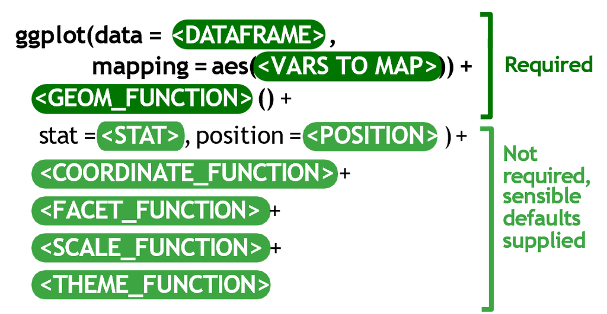

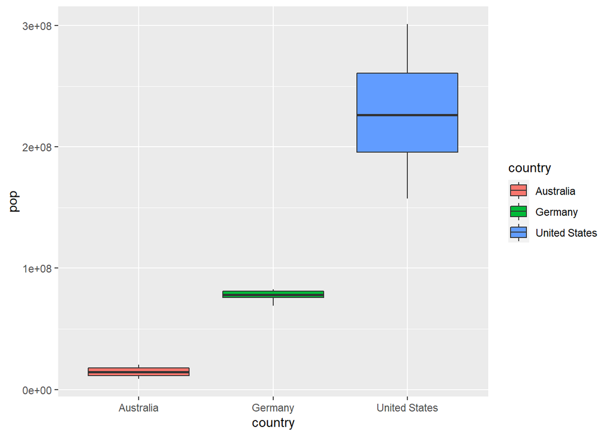

```r
# Boxplot showing distributions of population size for each country
ggplot(data = gap_mini,
       mapping = aes(x = country,
                     y = pop,
                     fill = country)) +
  geom_boxplot()
```

New component: scales

- gg syntax image, recap what we did

Let’s create a new subset of countries from `gapminder`, and this time we will plot line graphs changes in income per person (**`gdpPercap`**) over time (`years`).

```r
# Data subset to include India, China, and Thailand
gap_mini2 <- filter(gapminder,
                    country %in% c("India",
                                   "China",
                                   "Thailand"))
gap_mini2
```

| country | continent | year | lifeExp | pop | gdpPercap |
| --- | --- | --- | --- | --- | --- |
| China | Asia | 1952 | 44 | 556263527 | 400.448611 |
| China | Asia | 1957 | 50.54896 | 637408000 | 575.9870009 |
| China | Asia | 1962 | 44.50136 | 665770000 | 487.6740183 |
| China | Asia | 1967 | 58.38112 | 754550000 | 612.7056934 |
| China | Asia | 1972 | 63.11888 | 862030000 | 676.9000921 |
| China | Asia | 1977 | 63.96736 | 943455000 | 741.2374699 |
| China | Asia | 1982 | 65.525 | 1000281000 | 962.4213805 |
| China | Asia | 1987 | 67.274 | 1084035000 | 1378.904018 |
| China | Asia | 1992 | 68.69 | 1164970000 | 1655.784158 |
| China | Asia | 1997 | 70.426 | 1230075000 | 2289.234136 |

[output cut: 26 more lines]

We can use the previous code to update the `data` argument and change the `y` mapping from `lifeExp` to `gdpPercap`:

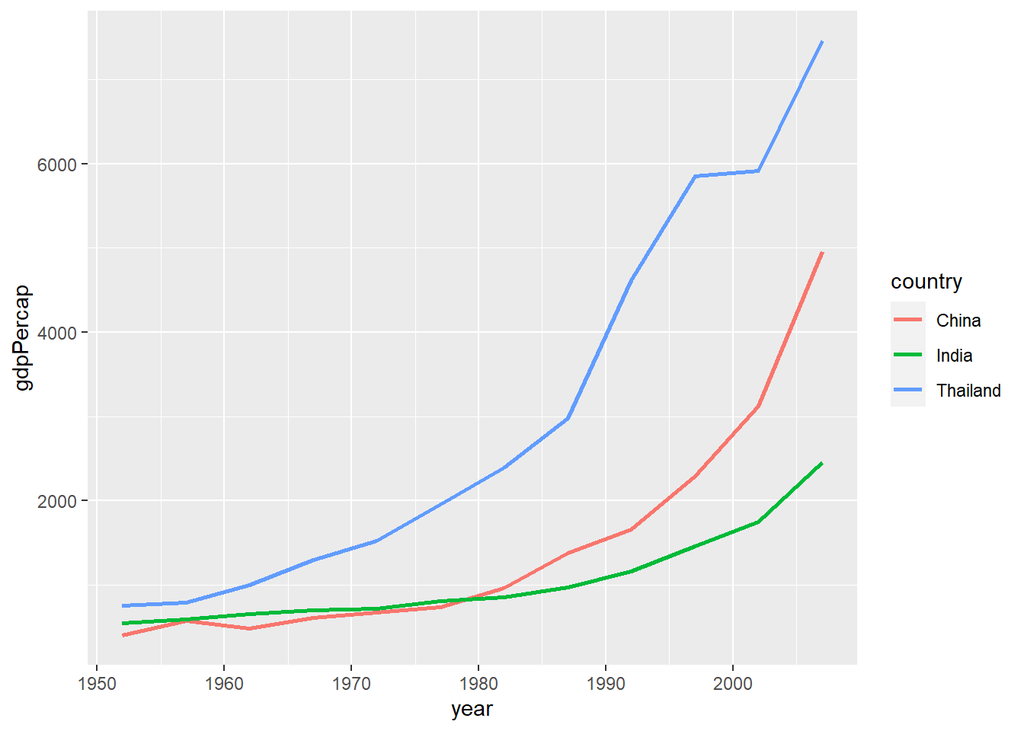

```r
ggplot(data = gap_mini2,
       mapping = aes(x = year,
                     y = gdpPercap,
                     color = country)) +
  geom_line(size = 1)
```

All show exponential growth curves. In theme with what we saw in previous plots, that things are generally improving for the majority of people.

## 9.1 Scale breaks

The x-axis for `year` in the previous plots ranges from 1950 to 2010, and is labeled every 10 years. This doesn’t match up with the years in the dataset.

```r
gap_mini2$year %>% unique()
```

```
##  [1] 1952 1957 1962 1967 1972 1977 1982 1987 1992 1997 2002 2007
```

we have 12 specific years so we should label them as such.

We can give ggplot a vector of numbers to label these years

```r
c(1952, 1957, 1962, 1967, 1972, 1977, 1982, 1987, 1992, 1997, 2002, 2007)
```

```
##  [1] 1952 1957 1962 1967 1972 1977 1982 1987 1992 1997 2002 2007
```

```r
seq(from = 1952, to = 2007, by = 5)
```

```
##  [1] 1952 1957 1962 1967 1972 1977 1982 1987 1992 1997 2002 2007
```

```r
gap_years <- seq(from = 1952, to = 2007, by = 5)
```

To make the years match up exactly with the dataset:

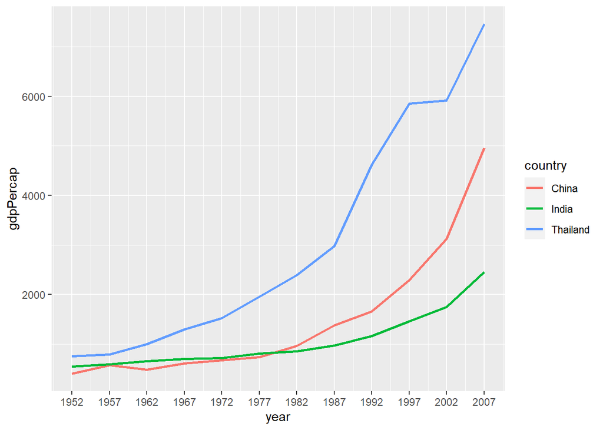

```r
ggplot(data = gap_mini2,
       mapping = aes(x = year,
                     y = gdpPercap,
                     color = country)) +
  geom_line(size = 1) +
  scale_x_continuous(breaks = gap_years)
```

We can add another scale function to customize our y-axis values, `scale_y_continous()`.

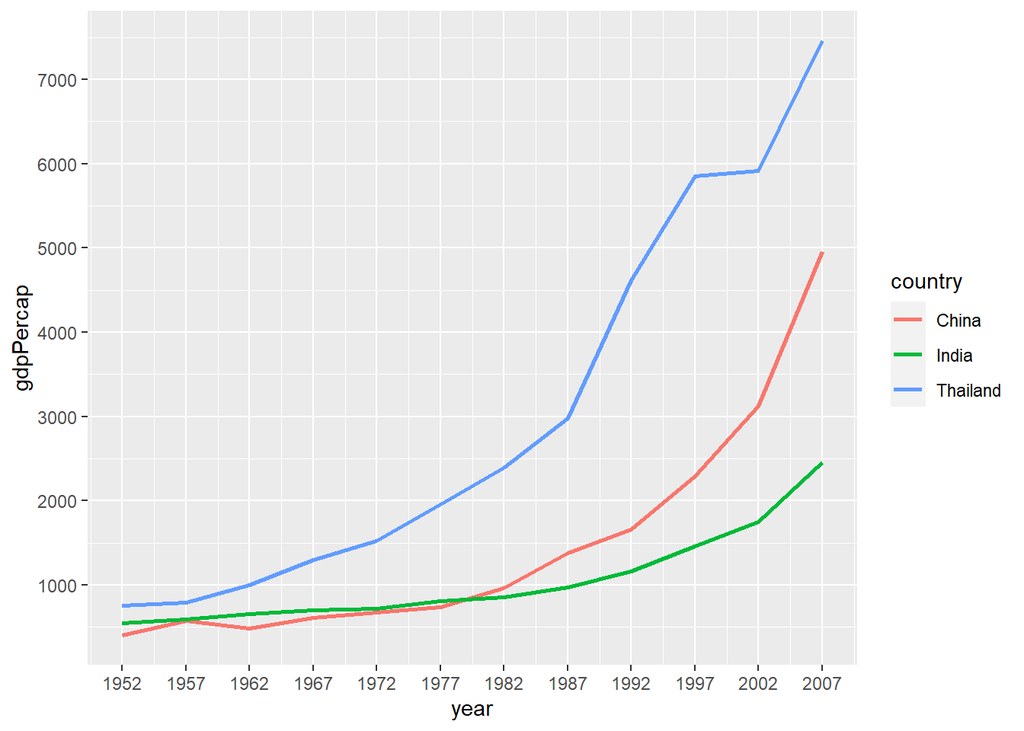

```r
ggplot(data = gap_mini2,
       mapping = aes(x = year,
                     y = gdpPercap,
                     color = country)) +
  geom_line(size = 1) +
  scale_x_continuous(breaks = gap_years) +
  scale_y_continuous(breaks = seq(from = 1000, to = 7000, by = 1000))
```

## 9.2 Logarithmic scaling

In the last two mini sets, I chose three countries that had similar range of GDP or life expectancy for good scaling and readability so that we can make out these changes.

But if we add a country to the group that significantly differs, default scaling is not so great. We’ll look at an example of this.

Let’s add New Zealand.

```r
# Data subset to include India, China, Thailand, and New Zealand
gap_mini3 <- filter(gapminder,
                    country %in% c("India",
                                   "China",
                                   "Thailand",
                                   "New Zealand"))
gap_mini3
```

| country | continent | year | lifeExp | pop | gdpPercap |
| --- | --- | --- | --- | --- | --- |
| China | Asia | 1952 | 44 | 556263527 | 400.448611 |
| China | Asia | 1957 | 50.54896 | 637408000 | 575.9870009 |
| China | Asia | 1962 | 44.50136 | 665770000 | 487.6740183 |
| China | Asia | 1967 | 58.38112 | 754550000 | 612.7056934 |
| China | Asia | 1972 | 63.11888 | 862030000 | 676.9000921 |
| China | Asia | 1977 | 63.96736 | 943455000 | 741.2374699 |
| China | Asia | 1982 | 65.525 | 1000281000 | 962.4213805 |
| China | Asia | 1987 | 67.274 | 1084035000 | 1378.904018 |
| China | Asia | 1992 | 68.69 | 1164970000 | 1655.784158 |
| China | Asia | 1997 | 70.426 | 1230075000 | 2289.234136 |

[output cut: 38 more lines]

Now we will recreate the plot of GDP over time with the new data subset:

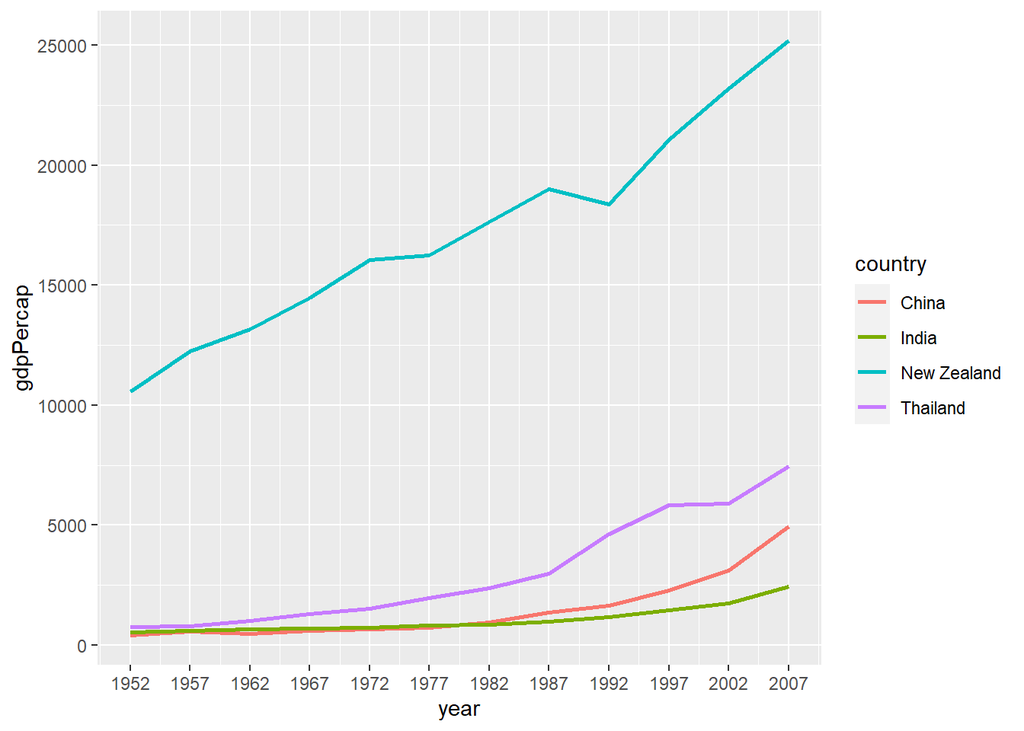

```r
ggplot(data = gap_mini3,
       mapping = aes(x = year,
                     y = gdpPercap,
                     color = country)) +
  geom_line(size = 1) +
  scale_x_continuous(breaks = gap_years)
```

The curves for India and China show an exponential increase in GDP per capita. However, the y-axes values for these two countries are much lower than that of New Zealand, so the lines are a bit squashed together. This makes it hard to read patterns in the data.

In addition, the large empty area in the middle is not a great use of plot space.

We can address this by log-transforming the y-axis using a scale function. The one we need for this plot is called `scale_y_log10()`, which does pretty much exactly what the name suggests - transforms the y-axis to logarithmic scale.

We will add this function on a new line after a `+` sign, as usual:

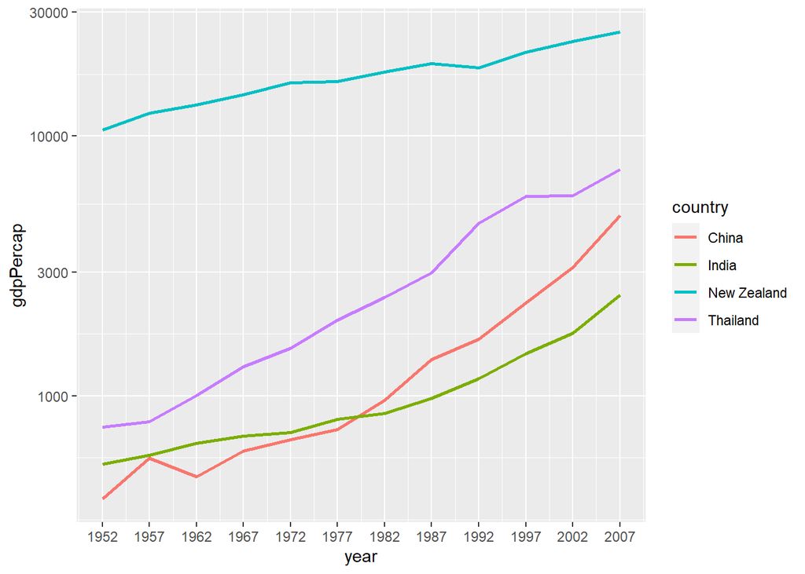

```r
ggplot(data = gap_mini3,
       mapping = aes(x = year,
                     y = gdpPercap,
                     color = country)) +
  geom_line(size = 1) +
  scale_x_continuous(breaks = gap_years) +
  scale_y_log10()
```

The grid lines show that the scale is nonlinear.

pop vs year for uganda, log scale

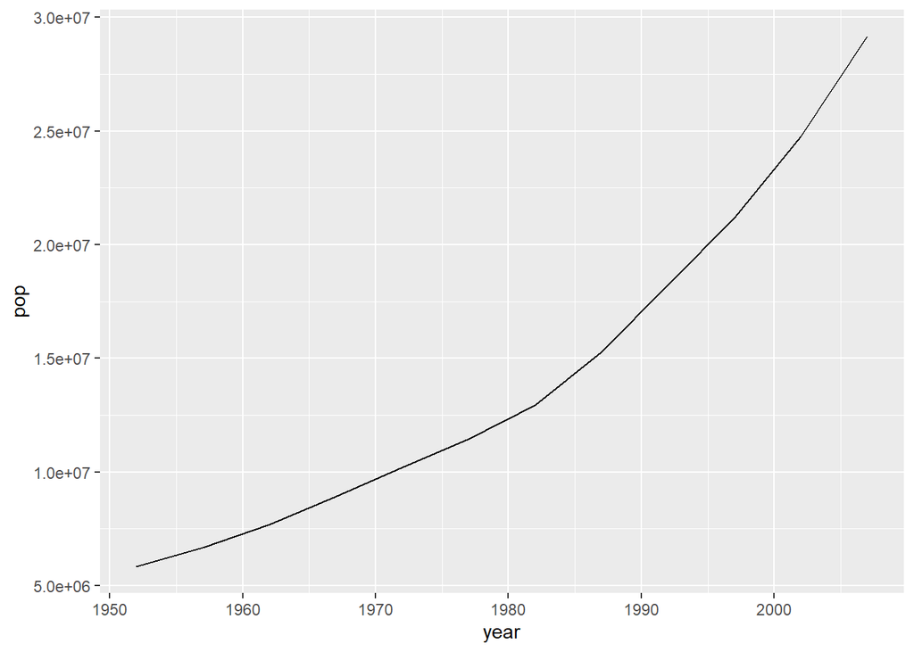

```r
gapminder %>%
  filter(country == "Uganda") %>%
  ggplot(aes(x = year, y = pop)) +
  geom_line()
```

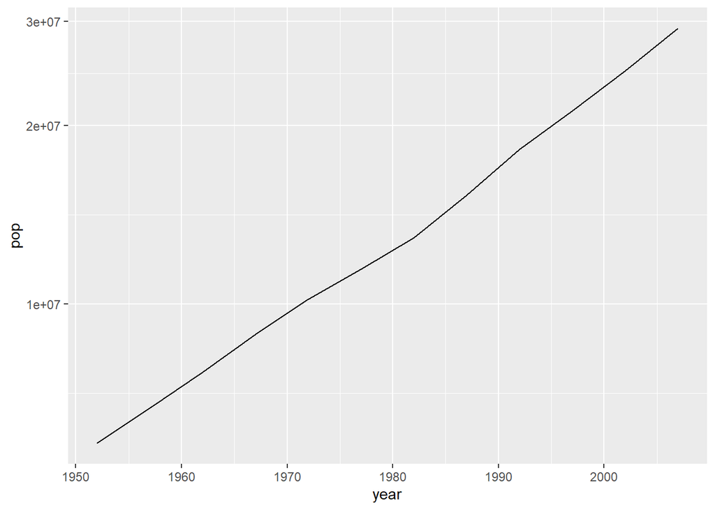

```r
gapminder %>%
  filter(country == "Uganda") %>%
  ggplot(aes(x = year, y = pop)) + geom_line() + scale_y_log10()
```

So far, we haven’t added or customized text in plots. Next, we will rename the axis labels, and add informative text to the plot.

# 10 Labeling with `labs()`

Plots ought to be informative enough that the reader can see the story behind the data analysis just by looking at it, without needing to refer additional documentation. Hence, graphs need good labels.

You can add labels to a plot with the `labs()` function. Arguments we can specify with the `labs()` function include:

- `title`: Add a title above the plot
- `subtitle`: Add a subtitle below the title
- `x`: Rename the x-axis
- `y`: Rename the y-axis
- `caption`: Add caption below the plot

Let’s start with this plot and start adding labels to it:

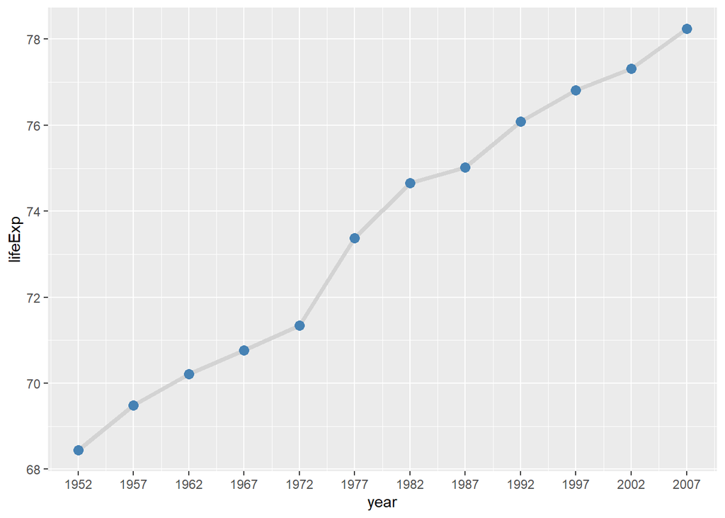

```r
# Time series plot of life expectancy in the United States
ggplot(data = gap_US,
       mapping = aes(x = year,
                     y = lifeExp)) +
  geom_line(size = 1.5,
            color = "lightgrey") +
  geom_point(size = 3,
             color = "steelblue") +
  scale_x_continuous(breaks = gap_years)
```

We add the `labs()` to our code using a `+` sign.

First we will add the `x` and `y` arguments to `labs()`, and change the axis titles from the default (variable name) to something more informative.

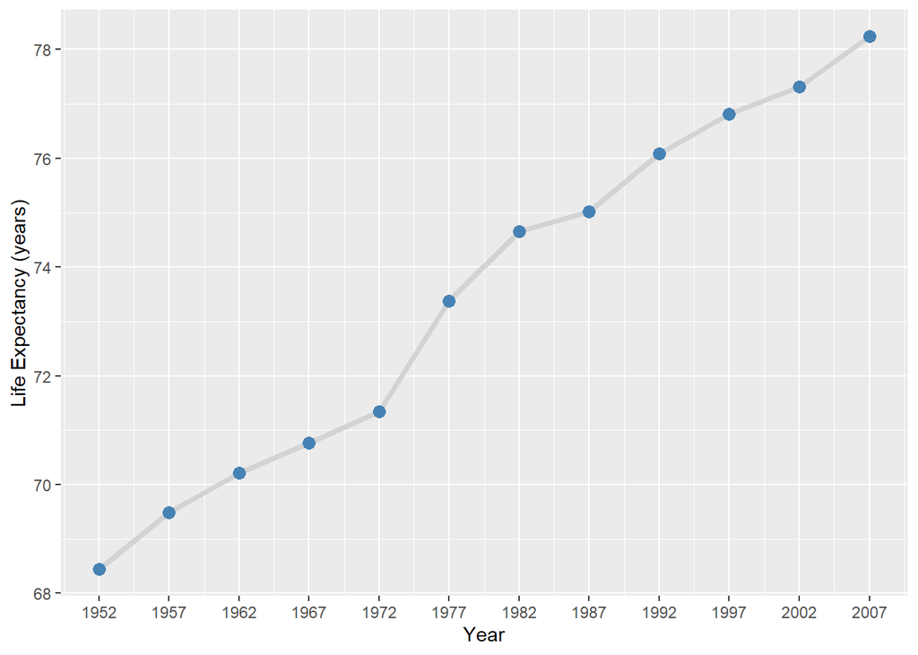

```r
# Rename axis titles
ggplot(data = gap_US,
       mapping = aes(x = year,
                     y = lifeExp)) +
  geom_line(size = 1.5,
            color = "lightgrey") +
  geom_point(size = 3,
             color = "steelblue") +
  scale_x_continuous(breaks = gap_years) +
  labs(x = "Year",
       y = "Life Expectancy (years)")
```

Next we supply a character string to the `title` argument to add large text at the top-left corner above the plot.

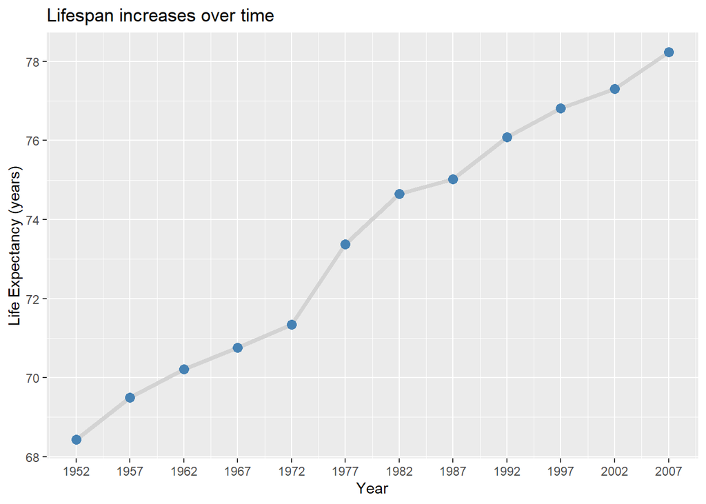

```r
# Add main title describing the relationship shown in the plot
ggplot(data = gap_US,
       mapping = aes(x = year,
                     y = lifeExp)) +
  geom_line(size = 1.5,
            color = "lightgrey") +
  geom_point(size = 3,
             color = "steelblue") +
  scale_x_continuous(breaks = gap_years) +
  labs(x = "Year",
       y = "Life Expectancy (years)",
       title = "Lifespan increases over time")
```

The `subtitle` argument adds smaller text below the main title.

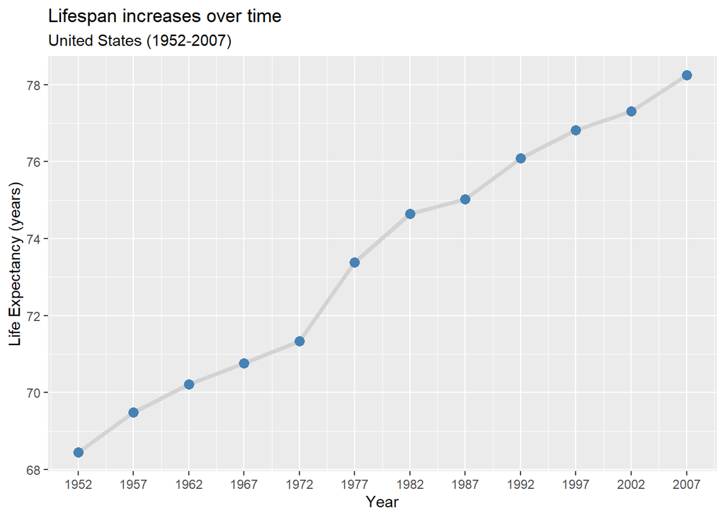

```r
# Add subtitle with location and time frame
ggplot(data = gap_US,
       mapping = aes(x = year,
                     y = lifeExp)) +
  geom_line(size = 1.5,
            color = "lightgrey") +
  geom_point(size = 3,
             color = "steelblue") +
  scale_x_continuous(breaks = gap_years) +
  labs(x = "Year",
       y = "Life Expectancy (years)",
       title = "Lifespan increases over time",
       subtitle = "United States (1952-2007)")
```

Finally, we can supply the `caption` argument to add small text to the bottom-right corner below the plot.

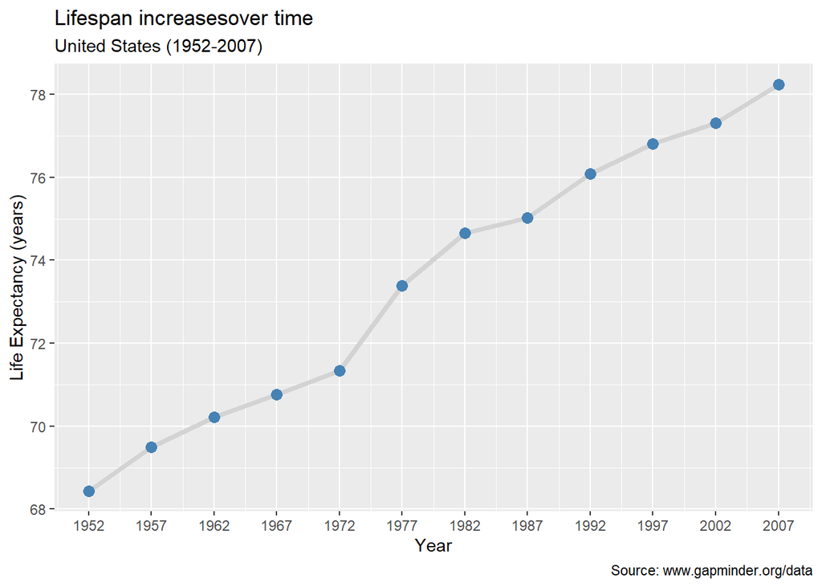

```r
# line graph with improved labeling
ggplot(data = gap_US,
       mapping = aes(x = year,
                     y = lifeExp)) +
  geom_line(size = 1.5,
            color = "lightgrey") +
  geom_point(size = 3,
             color = "steelblue") +
  scale_x_continuous(breaks = gap_years) +
  labs(x = "Year",
       y = "Life Expectancy (years)",
       title = "Lifespan increasesover time",
       subtitle = "United States (1952-2007)",
       caption = "Source: www.gapminder.org/data")
```

# 11 Faceting plots with `facet_wrap()`

Faceting creates **small multiples** of a plot, where each panel contains a subset of the data.

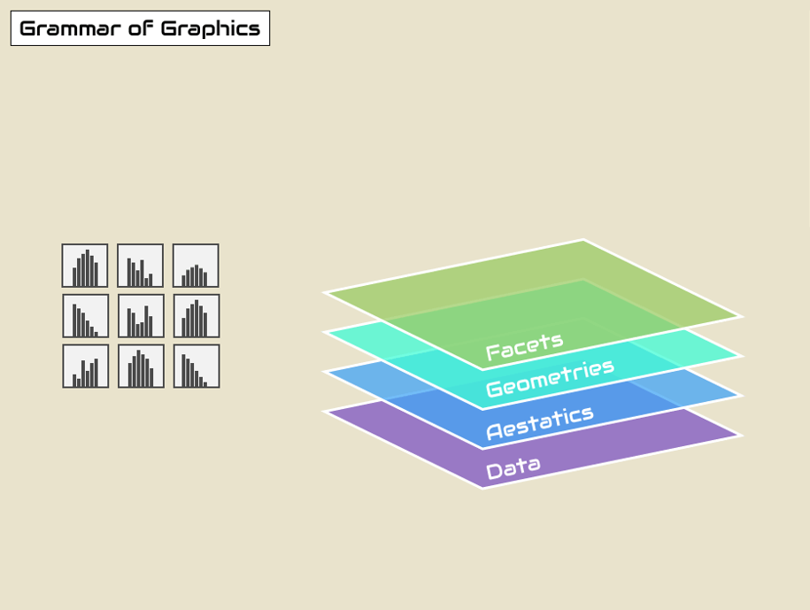

When we **facet** a graphs, it gets split up into **multiple panels**, one for each level of a categorical variable.

It is easiest to understand this with an example.

Let’s say we interested in comparing time series plots of **life expectancy** among different countries within a continent.

We will use the **`facet_wrap()`** function to separate line graphs of `lifeExp` vs. `year` for each `country` in the **Americas** `continent` of `gapminder`.

First let’s subset the `gapminder` data frame to only include data from the Americas.

```r
# Create a new data frame for the Americas
gap_americas <- dplyr::filter(gapminder,
                              continent == "Americas")
gap_americas
```

| country | continent | year | lifeExp | pop | gdpPercap |
| --- | --- | --- | --- | --- | --- |
| Argentina | Americas | 1952 | 62.485 | 17876956 | 5911.315053 |
| Argentina | Americas | 1957 | 64.399 | 19610538 | 6856.856212 |
| Argentina | Americas | 1962 | 65.142 | 21283783 | 7133.166023 |
| Argentina | Americas | 1967 | 65.634 | 22934225 | 8052.953021 |
| Argentina | Americas | 1972 | 67.065 | 24779799 | 9443.038526 |
| Argentina | Americas | 1977 | 68.481 | 26983828 | 10079.02674 |
| Argentina | Americas | 1982 | 69.942 | 29341374 | 8997.897412 |
| Argentina | Americas | 1987 | 70.774 | 31620918 | 9139.671389 |
| Argentina | Americas | 1992 | 71.868 | 33958947 | 9308.41871 |
| Argentina | Americas | 1997 | 73.275 | 36203463 | 10967.28195 |

[output cut: 290 more lines]

Now that the data is ready, we can plot separate line graphs for each `country` in the Americas.

```r
# View countries
gap_americas$country %>% unique()
```

```
##  [1] Argentina           Bolivia             Brazil
##  [4] Canada              Chile               Colombia
##  [7] Costa Rica          Cuba                Dominican Republic
## [10] Ecuador             El Salvador         Guatemala
## [13] Haiti               Honduras            Jamaica
## [16] Mexico              Nicaragua           Panama
## [19] Paraguay            Peru                Puerto Rico
## [22] Trinidad and Tobago United States       Uruguay
## [25] Venezuela
## 142 Levels: Afghanistan Albania Algeria Angola Argentina Australia ... Zimbabwe
```

We do this by adding `facet_wrap(~country)` to our plot code.

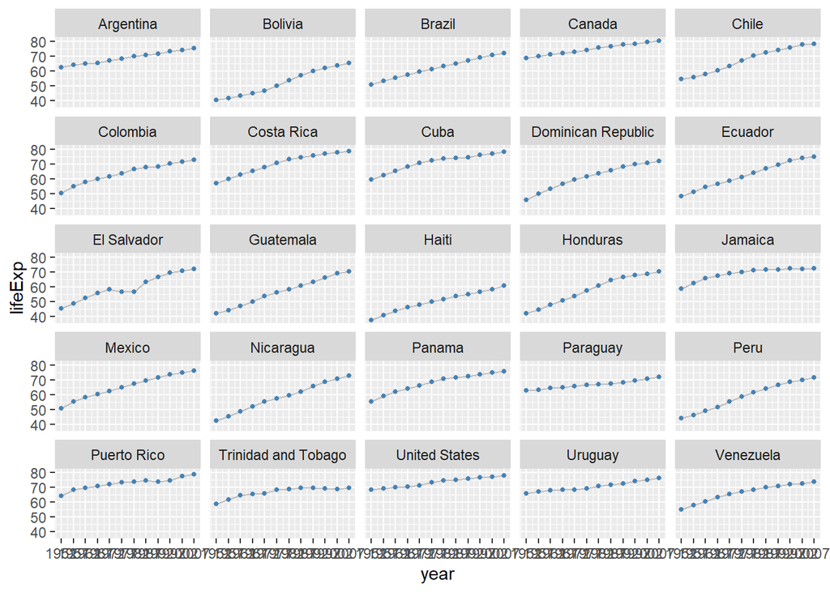

```r
# Plot life expectancy by year separately for each country in the Americas

ggplot(data = gap_americas,
       mappin = aes(x=year,
                    y = lifeExp)) +
  geom_line(color = "grey") +
  geom_point(color = "steelblue",
             size = 1) +
  scale_x_continuous(breaks = gap_years) +
  facet_wrap(~country, ncol = 5)
```

From our faceted plot we can see that life expectancy increased from 1952 to 2007 in each country in the Americas, though some lagged behind.

The `~` is a “tilde” and can generally be found on the key next to the “1” key on most keyboards. The tilde is required and you’ll receive the error `Error in as.quoted(facets) : object 'country' not found` if you don’t include it in `facet_wrap()`.

Let’s add text to this plot with `labs()`:

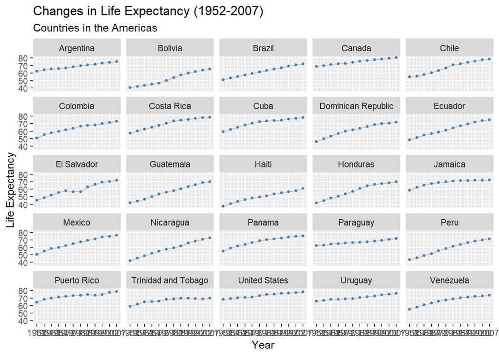

```r
# Add labels
ggplot(data = gap_americas,
       mappin = aes(x=year,
                    y = lifeExp)) +
  geom_line(color = "grey") +
  geom_point(color = "steelblue",
             size = 1) +
  scale_x_continuous(breaks = gap_years) +
  facet_wrap(~country,
             ncol = 5) +
  labs(title = "Changes in Life Expectancy (1952-2007)",
       subtitle = "Countries in the Americas",
       x = "Year",
       y = "Life Expectancy")
```

The `ncol` option controls the number of columns. Note that any general aesthetic settings (e.g., x, y, color) are applied to all of the panels.

Sometimes we want to be able to make multiple plots of the same variables across different categories. This can be achieved with minimal repetition using faceting.

# 12 Preview: Themes

In our faceted plot above, the *x*-axis labels are hard to read, and the plot looks a little busy. In the next lesson, you will learn how to use `theme` functions to tidy up a `ggplot` graphic.

As a sneak preview, here we use two theme functions to simplify the background color, rotate the x-axis text, and make the font size smaller.

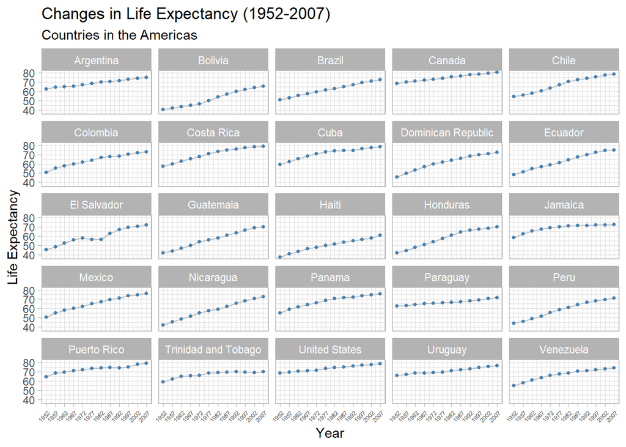

```r
# Faceted plot with enhanced theme
ggplot(data = gap_americas,
       mapping = aes(x=year,
                     y = lifeExp)) +
  geom_line(color="grey") +
  geom_point(color = "steelblue",
             size = 1) +
  scale_x_continuous(breaks = gap_years) +
  facet_wrap(~country, ncol = 5) +
  labs(title = "Changes in Life Expectancy (1952-2007)",
       subtitle = "Countries in the Americas",
       x = "Year",
       y = "Life Expectancy") +
  theme_light() +
  theme(axis.text.x = element_text(angle = 45,
                                   hjust = 1,
                                   size = 5))
```

# 13 Wrap up

Line graphs, just like scatterplots, display the relationship between two numerical variables. When one of the two variables represents time, a line graph can be a more effective method of displaying relationship. Therefore, it is preferred to use line graphs over scatterplots when the variable on the x-axis represents time.

# Contributors

The following team members contributed to this lesson:

- [JOY VAZ](https://thegraphcourses.org/members/joy)  
  R Developer and Instructor, the GRAPH Network

  Loves doing science and teaching science
- [ADMIN TEAM](https://thegraphnetwork.training/members/admin/)  
  GRAPH Courses Administration Team

  The GRAPH Courses team is building epidemiological training courses to enhance disease surveillance and data science for public health across the globe

# References

Some material in this lesson was adapted from the following sources:

- Ismay, Chester, and Albert Y. Kim. 2022. *A ModernDive into R and the Tidyverse*. https://moderndive.com/.
- Kabacoff, Rob. 2020. *Data Visualization with R*. https://rkabacoff.github.io/datavis/.
- https://www.rebeccabarter.com/blog/2017-11-17-ggplot2_tutorial/

This work is licensed under the [Creative Commons Attribution Share Alike](https://creativecommons.org/licenses/by-sa/4.0/) license.